# Finding Communities

Duy Bui

23 April 2016

# 1. Data loading and processing

```r
library(igraph)
library(knitr)
```

The data includes the following 3 files:

- jira.csv: Data from Jira (Task tracker)
- effort_on_tasks.csv: Effort on task
- effort_on_repos.csv: Coding effort (CE) on repositories

```r
jira <- read.csv(file = paste(WORKSPACE, "jira.csv", sep = "/"), header = TRUE, sep = ",",
                 stringsAsFactors = FALSE, strip.white = TRUE)

tasks <- read.csv(file = paste(WORKSPACE, "effort_on_tasks.csv", sep = "/"), header = TRUE,
                  sep = ",", stringsAsFactors = FALSE, strip.white = TRUE)

repos <- read.csv(file = paste(WORKSPACE, "effort_on_repos.csv", sep = "/"), header = TRUE,
                  sep = ",", stringsAsFactors = FALSE, strip.white = TRUE)
```

## Pre-processing data

Pre-processing data will contain two following tasks:

- Filter out bad data, i.e. missing values on Worker.ID. and Task.ID
- Deselect unneccessary data fields, such as date

```r
# Remove missing values
jira <- subset(jira, !is.na(jira$Worker.Id) & !is.na(jira$Task.Id))
repos <- subset(repos, !is.na(repos$Worker.ID))
tasks <- subset(tasks, !is.na(tasks$Worker.ID) & tasks$Task.id != "")

# Deselect unneccessary data fields
jira <- subset(jira, select = c("Worker.Id", "Task.Id"))
repos <- subset(repos, select = -c(Month..Day..Year.of.Date))
tasks <- subset(tasks, select = -c(Date))
```

# 2. Finding communities

To start off, we define our graph with:

- vertex: a worker or a task
- edge: a connection from a worker to a task

This graph could be built from the jira data. We use 10% random data first to test the speed of different algorithms

```r
# Take a sample of 10% data
jira_sample_10 <- jira[sample(nrow(jira), nrow(jira)*0.1), ]

# Create an edge-list data frame
jira_edgeweight_10 <- as.data.frame(table(jira_sample_10))
# Deselect any edge with weight as 0.
jira_edgeweight_10 <- subset(jira_edgeweight_10, jira_edgeweight_10$Freq > 0)

# Generate a graph with vertices and edges
jira_graph_10 <- graph_from_edgelist(as.matrix(jira_edgeweight_10[,1:2]), directed = FALSE)
# Add weight into each edge
E(jira_graph_10)$weight = jira_edgeweight_10[,3]
```

Using two first common algorithms:

- fast greedy: a bottom-down hierarchical approach to optimise the modularity
- walktrap: random walk approach

```r
# Fast greedy community detection
fc_10 <- fastgreedy.community(jira_graph_10, weights = E(jira_graph_10)$weight)
nrow(sizes(fc_10))
```

```
## [1] 1430
```

```r
modularity(fc_10)
```

```
## [1] 0.9782564
```

```r
# Walktrap community detection
wt_10 <- walktrap.community(jira_graph_10, weights = E(jira_graph_10)$weight)
nrow(sizes(wt_10))
```

```
## [1] 1656
```

```r
modularity(wt_10)
```

```
## [1] 0.9693914
```

- Label propagation: each node is assigned a k label which is updated during each iterative run
- Info map: find the community that minimizes the length of random walker trajectory

```r
# Label propagation
lp_10 <- label.propagation.community(jira_graph_10, weights = E(jira_graph_10)$weight)
nrow(sizes(lp_10))
```

```
## [1] 2362
```

```r
modularity(lp_10)
```

```
## [1] 0.9086088
```

```r
# Leading eigenvector
ic_10 <- infomap.community(jira_graph_10, e.weights = E(jira_graph_10)$weight)
nrow(sizes(ic_10))
```

```
## [1] 2272
```

```r
modularity(ic_10)
```

```
## [1] 0.9175778
```

Another considerable algorithm is using Self-organised map (SOM) with a greedy fine-tuning algorithm. However, [this algorithm](https://machinelearningnow.wordpress.com/2014/08/22/community-detection/) is highly complex and only suitable for small graphs though it is proved to perform better than fast greedy. Trying this algorithm on the graph of 10% data (graph of 29k edges), the computer was freezing halfway and unable to produce the final result.

Since fast greedy and walktrap have a quite similar performance, we try these both on 50% of data.

```r
# Remove all variables of the previous run
rm(jira_edgeweight_10, jira_graph_10, jira_sample_10, fc_10, wt_10, lp_10, ic_10)
```

```r
# Take a sample of 10% data
jira_sample_50 <- jira[sample(nrow(jira), nrow(jira)*0.5), ]

# Create an edge-list data frame
jira_edgeweight_50 <- as.data.frame(table(jira_sample_50))
# Deselect any edge with weight as 0.
jira_edgeweight_50 <- subset(jira_edgeweight_50, jira_edgeweight_50$Freq > 0)

# Generate a graph with vertices and edges
jira_graph_50 <- graph_from_edgelist(as.matrix(jira_edgeweight_50[,1:2]), directed = FALSE)
# Add weight into each edge
E(jira_graph_50)$weight = jira_edgeweight_50[,3]

# Save the graph
save(jira_graph_50, file = "jira_graph_50.Rdata")
```

```r
# This is to reduce the compiling time
load("jira_graph_50.Rdata")

# Fast greedy community detection
fc_50 <- fastgreedy.community(jira_graph_50, weights = E(jira_graph_50)$weight)
nrow(sizes(fc_50))
```

```
## [1] 972
```

```r
modularity(fc_50)
```

```
## [1] 0.971044
```

```r
# Walktrap community detection
wt_50 <- walktrap.community(jira_graph_50, weights = E(jira_graph_50)$weight)
nrow(sizes(wt_50))
```

```
## [1] 1724
```

```r
modularity(wt_50)
```

```
## [1] 0.9526203
```

```r
rm(jira_graph_50, fc_50, wt_50)
```

When the sample data increases, fast greedy performs far better than walktrap with a smaller community size (972 versus 1724) and higher modularity (0.971044 versus 0.9526203).

Similarly, we perform fast greedy algorithm on the whole data.

```r
# The following graph was prepared the same way as with 10% and 50% of data but with 100% of data.
load("jira_graph.Rdata")

fc <- fastgreedy.community(jira_graph, weights = E(jira_graph)$weight)
nrow(sizes(fc))
```

```
## [1] 842
```

```r
modularity(fc)
```

```
## [1] 0.9689408
```

So, we have 842 communities with a modularity of 0.9689408. Since the problem is to find working groups, we remove tasks from each community.

```r
# Retrieve the community from fast greedy (there are 842 communities)
com <- communities(fc)

# Retrieve the unique task id from the data
unique_task <- unique(jira$Task.Id)

# Remove any task elements from each community
working_groups <- lapply(com, function(x){setdiff(unlist(x), unique_task)})
```

We finally found 842 working groups (in the working_groups list).

# 3. Find reviewers/testers/developers

**Assumption:** Reviewers should have 0 coding efforts while developers must have much higher coding efforts than testers.

Based on that, we calculate the coding effort for each person in the repository data

```r
work_code <- aggregate(Coding.Effort ~ Worker.ID, data = repos, FUN = sum)
# number of workers who have coding effort
nrow(work_code)
```

```
## [1] 2621
```

```r
# number of unique workers on Jira database
length(unique(jira$Worker.Id))
```

```
## [1] 3287
```

```r
# number of common Workers on Jira and coding effort
length(intersect(unique(jira$Worker.Id), unique(repos$Worker.ID)))
```

```
## [1] 536
```

```r
# number of common Workers on Jira and task effort
length(intersect(unique(jira$Worker.Id), unique(tasks$Worker.ID)))
```

```
## [1] 229
```

As can be seen, there are 3287 unique workers on Jira data, while this number is 2621 on the coding effort data. However, the number of workers who appear on both data is only 536. This means we can only predict the role of 536 workers in the community. (Needless to say, jira and task effort data only share 229 workers in common)

On the other hand, it is quite obvious that developers have more coding effort than testers. Also, it is a rule of thumb that the ratio between testers and developers is normally 1:2 or 1:3. We assume that the ratio here is 3:7 (3 testers versus 7 developers). We plot a histogram to see if there is any abnormality

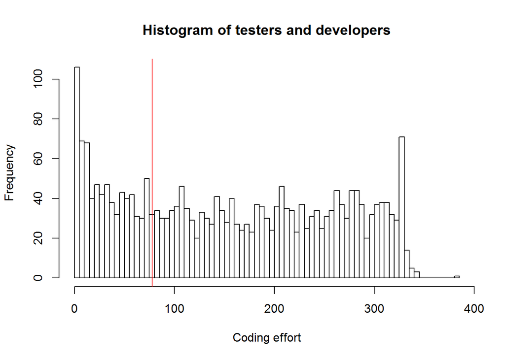

```r
# Subset the developers and testers only
dev_test <- subset(work_code, work_code$Coding.Effort !=0)
hist(dev_test$Coding.Effort, breaks = 100, main = "Histogram of testers and developers", xlab = "Coding effort")
abline(v = quantile(dev_test$Coding.Effort, 0.3), col = "red")
```

We set a thresold of 30% and identify the roles for each worker on jira data.

```r
jira_workers <- data.frame(Worker.ID = unique(jira$Worker.Id), role = "")
jira_workers$role <- as.character(jira_workers$role)

# Take the threshold at 30%
threshold = quantile(dev_test$Coding.Effort, 0.3)

jira_workers[jira_workers$Worker.ID %in% work_code[work_code$Coding.Effort == 0,"Worker.ID"],"role"] = "Reviewers"
jira_workers[jira_workers$Worker.ID %in% work_code[work_code$Coding.Effort > threshold,"Worker.ID"],"role"] = "Developers"
jira_workers[jira_workers$Worker.ID %in% work_code[work_code$Coding.Effort <= threshold & work_code$Coding.Effort > 0,"Worker.ID"],"role"] = "Testers"

# Print the result
table(jira_workers$role)
```

```
##
##            Developers  Reviewers    Testers
##       2751        343         37        156
```

# 4. Find people who work in isolation/work in a team

We could use the result from the community finding to solve this problem. Communities with only one worker means people who work in isolation and vice versa.

```r
# Set the condition for community whose size is 1
cond <- sapply(working_groups, function(x) length(x) == 1 )
# People who work on their own
isolation <- working_groups[cond]
# People who work in the team
team <- working_groups[!cond]
```

The results show that we have 584 employees who work in isolation, while there are 258 teams of multiple workers.

# Discussion

The input data is quite big (490909 rows for Jira), which normally requires big data technology. However, the edge-list representation of graph (where all the 0-weight edges are trimmed off) reduces the size of the data significantly, which makes it applicable to different algorithms in *igraph* library. Having said that, if the size of the data is higher, it is neccessary to work on big data technology such as MapReduce and GiraphX

Community on other data sets: The problem was solved by using Jira data, mainly based on the idea that workers are in the same community if they work on the same task. However, the same techniques could be applied to other data sets: - *Coding effort*: workers who work in the same repository/application are in the same community and vice versa - *Effort on task*: workers who work in the same repository/applications/tasks are in the same community and vice versa

Likewise, the final task of finding workers on the same team or in isolation could be different if the community is built from different data sets.

The second task of finding reviewers/developers/testers could be different if the assumption ratio of testers and developers is set differently. Nevertheless, for such tasks, it is the best to ask the clients for further information/clues of reviewers/testers/developers, so that the result will be more accurate.